# Carbon sequastration in shelterbelts surrounding Alberta cropland

Stephanie Flaman

1

Living Data Project

1,2

28. September 2022

# Abstract

Perennial vegetation surrounding cropland, such as trees and bushes, are beneficial because they store carbon (Gross et al., 2022). This is beneficial with respect to mitigating global warming because this woody vegetation absorbs atmospheric carbon dioxide. This means that perennial vegetation is great resource for absorbing atmospheric carbon dioxide and storing it, mitigating the increasing rate of global warming (Gross et al., 2022). For this mini LDP project, I found shelter belt data from Alberta that I am able to use to create a figure. Shelter belts are the perennial vegetation surrounding croplands.

# Introduction

There are many acres of cropland throughout Canada and knowing how much carbon is stored within perennial vegetation surrounding this cropland is important because this data helps researchers determine the amount of shelter belts that still need to be planted to mitigate global warming. Data collected between 1990 and 2000 has determined the amount of carbon stored in this perennial vegetation, but more research needs to be done to limit errors when collecting this data (Huffman et al., 2015).

# Methods

Methods for this type of research will include extensive field work with the use of drones, plant identification, and statistical analysis.

# Results

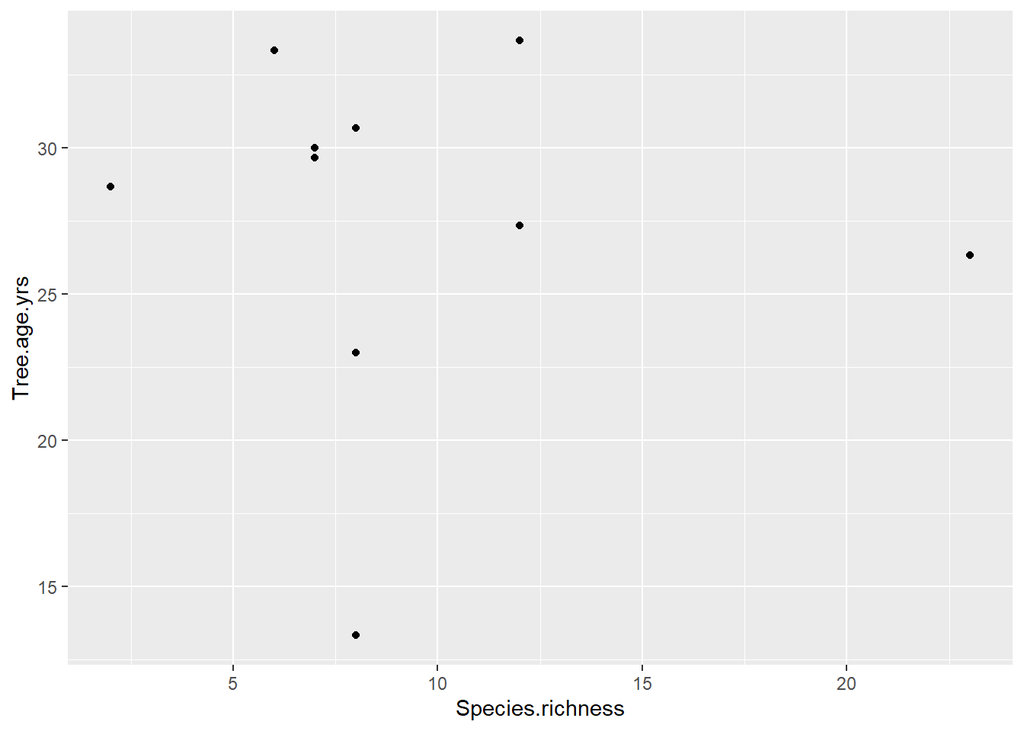

Data taken from https://doi.org/10.5061/dryad.0zpc86711.

# Discussion

Since no statistical analysis has yet to be ran on the data in this project, I am not able to write my discussion as of yet.

# References

Gross, C.D., Bork, E.W., Carlyle, C.N., Chang, S.X., 2022. Agroforestry perennials reduce nitrous oxide emissions and their live and dead trees increase ecosystem carbon storage. Global Change Biology 28, 5956–5972. https://doi.org/10.1111/gcb.16322

Huffman, T., Liu, J., McGovern, M., McConkey, B., Martin, T., 2015. Carbon stock and change from woody biomass on Canada’s cropland between 1990 and 2000. Agriculture, Ecosystems & Environment 205, 102–111. https://doi.org/10.1016/j.agee.2014.10.009